# Monitoramento Blend4

# PSI Base Geral Uniproponente

## Dia e Semana Raw

```
Período: 2026-11-05 00:00:00 → 2026-11-12 00:00:00
Volume total: 41,886
```

```
Semanas: 6 | Volume: 185,826
Período: 2026-10-04 00:00:00 → 2026-11-12 00:00:00
```

```
Target day: 2026-11-12
```

```
Target Week == 2026-11-01 (Última Semana Completa)
```

## PSI RAW BVS

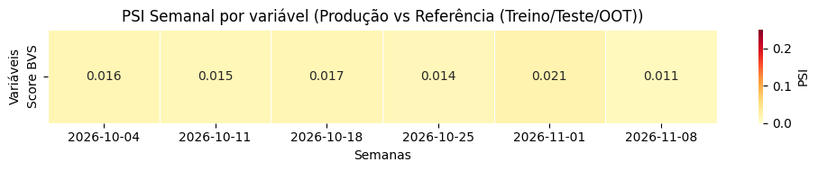

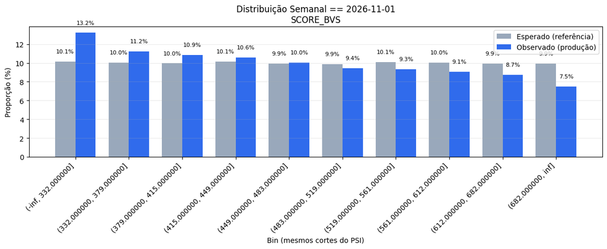

## PSI RAW Renda e Aluguel

Quantos % com predict_blend4 e renda 0?

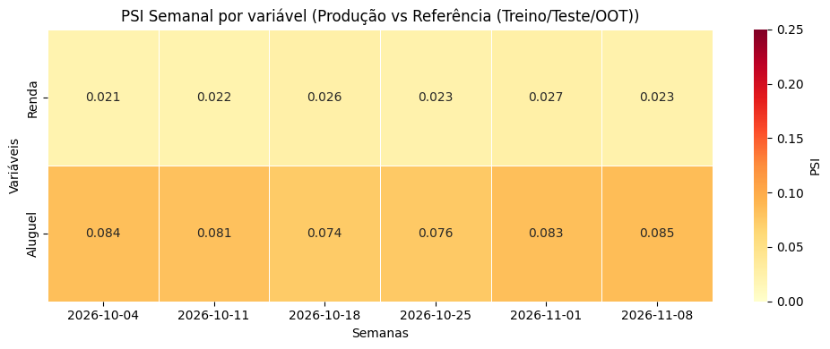

|  | income | rental_value |
| --- | --- | --- |
| count | 20578.000000 | 2.057800e+04 |
| mean | 6150.153562 | 1.458551e+07 |
| min | 548.000000 | 1.000000e+02 |
| 10% | 1438.500000 | 9.000000e+02 |
| 20% | 1712.500000 | 1.100000e+03 |
| 30% | 1986.500000 | 1.300000e+03 |
| 40% | 2329.000000 | 1.450000e+03 |
| 50% | 2945.500000 | 1.600000e+03 |
| 60% | 3973.000000 | 1.800000e+03 |
| 70% | 4863.500000 | 2.100000e+03 |
| 80% | 6507.500000 | 2.500000e+03 |
| 90% | 11028.500000 | 3.400000e+03 |
| max | 205500.000000 | 3.000892e+11 |
| std | 12255.252484 | 2.091938e+09 |

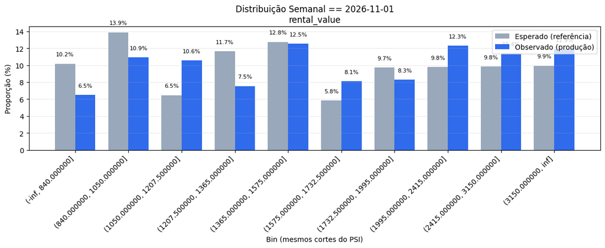

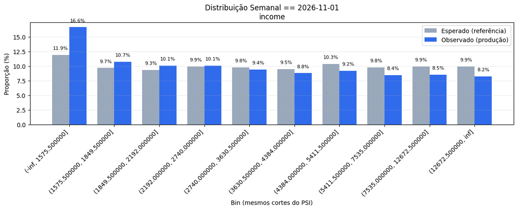

# Outras Análises

Análises Extras que servem para avaliar possíveis alterações que vemos na nossa base de leads.

## Comparação CR vs. Base Datalake PC Cidades / PC Imobiliárias

```
City safra (Blend3 < 01/09; Blend3+Blend4 >= 01/09): 281023
City freeze (>= 04/09): 246814
Agency (df_uniprop): 387339
city_safra rows: 277814
city_freeze rows: 246814
agency_safra rows: 44103
agency_freeze rows: 47579
```

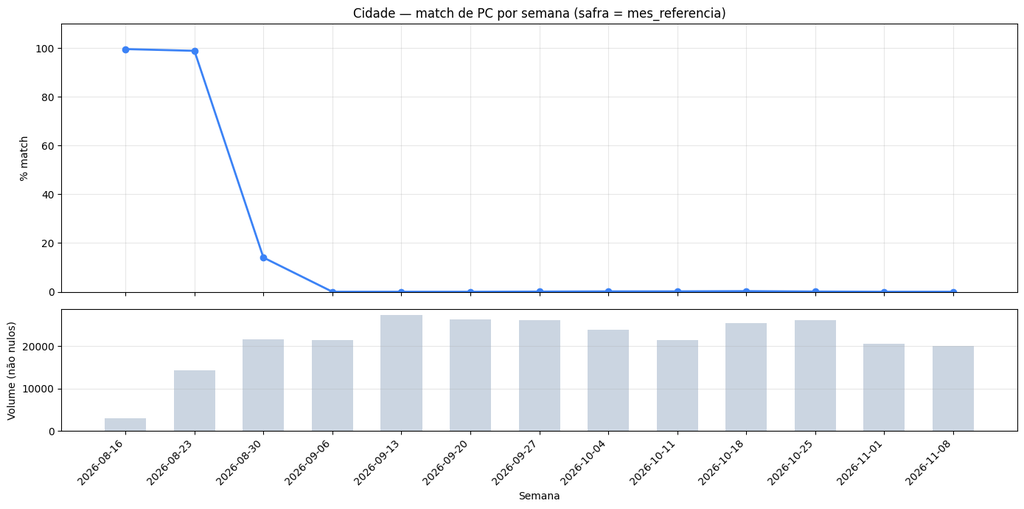

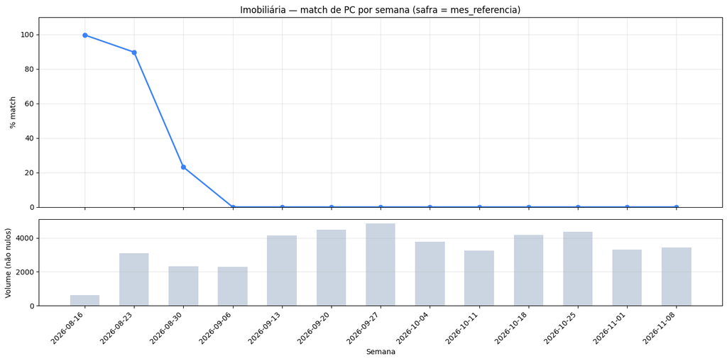

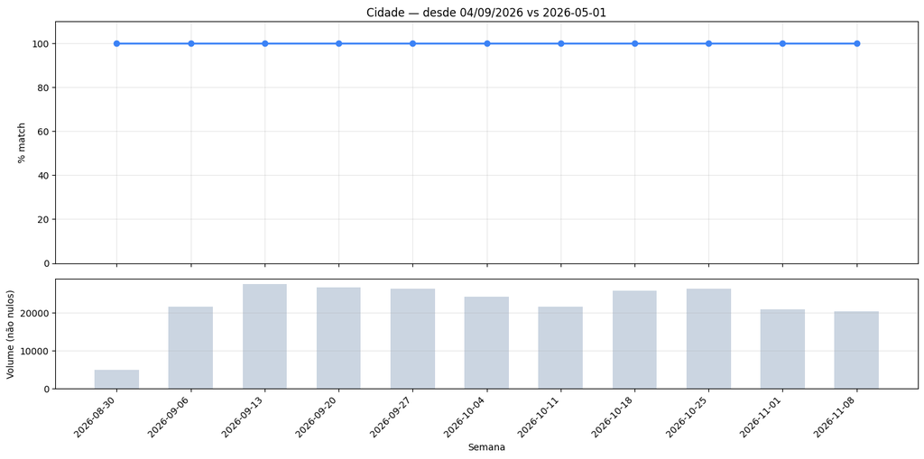

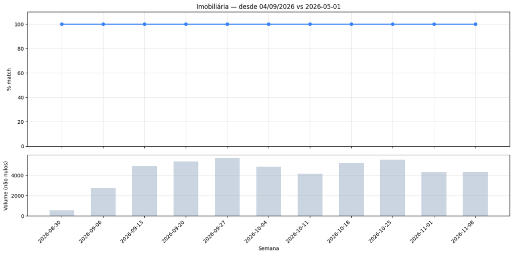

|  | contract_id | requested_at | message_decisao | year_week | week_start | safra_dt | id_key | value_prod | value_ref | diff | abs_diff |
| --- | --- | --- | --- | --- | --- | --- | --- | --- | --- | --- | --- |
| 62661 | 4544266 | 2026-08-21 | BLEND3_3 | 2026-08-16 | 2026-08-16 | 2026-08-01 | 4204202 | 0.156000 | 0.135667 | 0.020333 | 0.020333 |
| 31557 | 4547137 | 2026-08-21 | BLEND3_3 | 2026-08-16 | 2026-08-16 | 2026-08-01 | 3529401 | 0.087774 | 0.069620 | 0.018154 | 0.018154 |
| 114979 | 4549218 | 2026-08-22 | BLEND3_3 | 2026-08-16 | 2026-08-16 | 2026-08-01 | 3122306 | 0.167712 | 0.183087 | -0.015375 | 0.015375 |
| 170750 | 4549363 | 2026-08-22 | BLEND3_3 | 2026-08-16 | 2026-08-16 | 2026-08-01 | 4113700 | 0.102014 | 0.113262 | -0.011248 | 0.011248 |
| 88477 | 4545563 | 2026-08-21 | BLEND3_3 | 2026-08-16 | 2026-08-16 | 2026-08-01 | 3501608 | 0.099867 | 0.111111 | -0.011244 | 0.011244 |
| ... | ... | ... | ... | ... | ... | ... | ... | ... | ... | ... | ... |
| 166899 | 4944442 | 2026-11-12 | BLEND_4 | 2026-11-08 | 2026-11-08 | 2026-11-01 | 3545803 | 0.118577 | 0.118280 | 0.000298 | 0.000298 |
| 166909 | 4944580 | 2026-11-12 | BLEND_4 | 2026-11-08 | 2026-11-08 | 2026-11-01 | 3545803 | 0.118577 | 0.118280 | 0.000298 | 0.000298 |
| 138955 | 4944592 | 2026-11-12 | BLEND_4 | 2026-11-08 | 2026-11-08 | 2026-11-01 | 3545803 | 0.118577 | 0.118280 | 0.000298 | 0.000298 |
| 110953 | 4944744 | 2026-11-12 | BLEND_4 | 2026-11-08 | 2026-11-08 | 2026-11-01 | 3545803 | 0.118577 | 0.118280 | 0.000298 | 0.000298 |
| 166999 | 4945718 | 2026-11-12 | BLEND_4 | 2026-11-08 | 2026-11-08 | 2026-11-01 | 3545803 | 0.118577 | 0.118280 | 0.000298 | 0.000298 |

257397 rows × 11 columns

|  | contract_id | requested_at | message_decisao | year_week | week_start | safra_dt | id_key | value_prod | value_ref | diff | abs_diff |
| --- | --- | --- | --- | --- | --- | --- | --- | --- | --- | --- | --- |
| 18729 | 4546752 | 2026-08-21 | BLEND_4 | 2026-08-16 | 2026-08-16 | 2026-08-01 | 264 | 0.187500 | 0.162602 | 0.024898 | 0.024898 |
| 14326 | 4549621 | 2026-08-22 | BLEND_4 | 2026-08-16 | 2026-08-16 | 2026-08-01 | 11153 | 0.087866 | 0.096386 | -0.008519 | 0.008519 |
| 19086 | 4579657 | 2026-08-28 | BLEND_4 | 2026-08-23 | 2026-08-23 | 2026-08-01 | 1752 | 0.044444 | 0.133333 | -0.088889 | 0.088889 |
| 36396 | 4576576 | 2026-08-27 | BLEND_4 | 2026-08-23 | 2026-08-23 | 2026-08-01 | 11913 | 0.184466 | 0.114286 | 0.070180 | 0.070180 |
| 23227 | 4551709 | 2026-08-24 | BLEND_4 | 2026-08-23 | 2026-08-23 | 2026-08-01 | 35054 | 0.083969 | 0.147541 | -0.063572 | 0.063572 |
| ... | ... | ... | ... | ... | ... | ... | ... | ... | ... | ... | ... |
| 13092 | 4942593 | 2026-11-12 | BLEND_4 | 2026-11-08 | 2026-11-08 | 2026-11-01 | 1885 | 0.150376 | 0.150943 | -0.000567 | 0.000567 |
| 30899 | 4942743 | 2026-11-12 | BLEND_4 | 2026-11-08 | 2026-11-08 | 2026-11-01 | 1885 | 0.150376 | 0.150943 | -0.000567 | 0.000567 |
| 44056 | 4943275 | 2026-11-12 | BLEND_4 | 2026-11-08 | 2026-11-08 | 2026-11-01 | 1885 | 0.150376 | 0.150943 | -0.000567 | 0.000567 |
| 39728 | 4945286 | 2026-11-12 | BLEND_4 | 2026-11-08 | 2026-11-08 | 2026-11-01 | 1885 | 0.150376 | 0.150943 | -0.000567 | 0.000567 |
| 35421 | 4945542 | 2026-11-12 | BLEND_4 | 2026-11-08 | 2026-11-08 | 2026-11-01 | 1885 | 0.150376 | 0.150943 | -0.000567 | 0.000567 |

40175 rows × 11 columns

|  | contract_id | requested_at | message_decisao | year_week | week_start | safra_dt | id_key | value_prod | value_ref | diff | abs_diff |
| --- | --- | --- | --- | --- | --- | --- | --- | --- | --- | --- | --- |

|  | contract_id | requested_at | message_decisao | year_week | week_start | safra_dt | id_key | value_prod | value_ref | diff | abs_diff |
| --- | --- | --- | --- | --- | --- | --- | --- | --- | --- | --- | --- |

## Cidades/Imobiliária que deveriam estar sendo utilizadas na PC Cidades / PC Imobiliária

Cidades e imobiliárias que chegaram com a variável de PC nula, embora o ID exista em `df_city` / `df_agency` — nesses casos o PC deveria ter sido preenchido.

```
Cidade — contratos com PC nulo e ID no datalake: 35698 (211 cidades)
Imobiliária — contratos com PC nulo e ID no datalake: 19855 (187 imobiliárias)
```

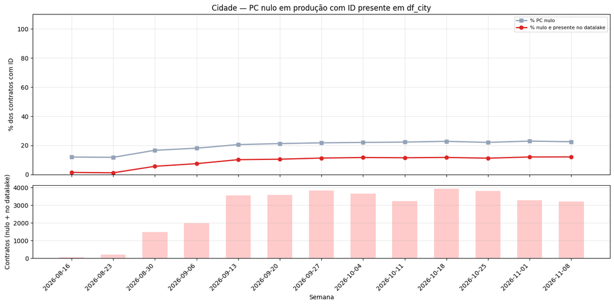

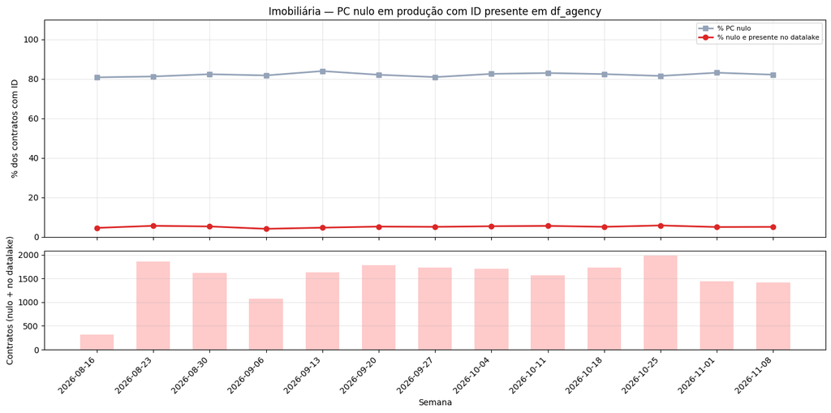

```
Resumo semanal — cidade
```

|  | Semana | Volume com ID | PC nulo | Nulo e no datalake | Nulo no lookup da safra/freeze | % PC nulo | % nulo e no datalake |
| --- | --- | --- | --- | --- | --- | --- | --- |
| 0 | 2026-08-16 | 3462 | 416 | 51 | 0 | 12.02 | 1.47 |
| 1 | 2026-08-23 | 16253 | 1921 | 195 | 2 | 11.82 | 1.2 |
| 2 | 2026-08-30 | 26061 | 4339 | 1476 | 1126 | 16.65 | 5.66 |
| 3 | 2026-09-06 | 26347 | 4766 | 1970 | 1566 | 18.09 | 7.48 |
| 4 | 2026-09-13 | 34799 | 7156 | 3552 | 3154 | 20.56 | 10.21 |
| 5 | 2026-09-20 | 33865 | 7196 | 3568 | 3069 | 21.25 | 10.54 |
| 6 | 2026-09-27 | 33776 | 7353 | 3822 | 3368 | 21.77 | 11.32 |
| 7 | 2026-10-04 | 31185 | 6872 | 3645 | 3192 | 22.04 | 11.69 |
| 8 | 2026-10-11 | 27933 | 6225 | 3218 | 2793 | 22.29 | 11.52 |
| 9 | 2026-10-18 | 33423 | 7618 | 3927 | 3386 | 22.79 | 11.75 |
| 10 | 2026-10-25 | 33934 | 7489 | 3811 | 3239 | 22.07 | 11.23 |
| 11 | 2026-11-01 | 27125 | 6226 | 3270 | 2819 | 22.95 | 12.06 |
| 12 | 2026-11-08 | 26377 | 5940 | 3193 | 2611 | 22.52 | 12.11 |

```
Resumo semanal — imobiliária
```

|  | Semana | Volume com ID | PC nulo | Nulo e no datalake | Nulo no lookup da safra/freeze | % PC nulo | % nulo e no datalake |
| --- | --- | --- | --- | --- | --- | --- | --- |
| 0 | 2026-08-16 | 6923 | 5593 | 313 | 54 | 80.79 | 4.52 |
| 1 | 2026-08-23 | 33334 | 27074 | 1860 | 341 | 81.22 | 5.58 |
| 2 | 2026-08-30 | 30794 | 25364 | 1618 | 389 | 82.37 | 5.25 |
| 3 | 2026-09-06 | 26645 | 21781 | 1080 | 325 | 81.75 | 4.05 |
| 4 | 2026-09-13 | 35250 | 29595 | 1635 | 604 | 83.96 | 4.64 |
| 5 | 2026-09-20 | 34247 | 28111 | 1776 | 673 | 82.08 | 5.19 |
| 6 | 2026-09-27 | 34320 | 27766 | 1734 | 804 | 80.9 | 5.05 |
| 7 | 2026-10-04 | 31744 | 26200 | 1703 | 676 | 82.54 | 5.36 |
| 8 | 2026-10-11 | 28321 | 23498 | 1568 | 591 | 82.97 | 5.54 |
| 9 | 2026-10-18 | 34089 | 28099 | 1727 | 720 | 82.43 | 5.07 |
| 10 | 2026-10-25 | 34444 | 28072 | 1983 | 721 | 81.5 | 5.76 |
| 11 | 2026-11-01 | 29077 | 24169 | 1442 | 572 | 83.12 | 4.96 |
| 12 | 2026-11-08 | 28151 | 23120 | 1416 | 567 | 82.13 | 5.03 |

```
Cidades com PC nulo apesar de existirem em df_city
```

|  | id_cidade_ibge | n_contratos | n_semanas | pc_datalake | pc_safra | n_na_safra | modelos | pct_na_safra |
| --- | --- | --- | --- | --- | --- | --- | --- | --- |
| 103 | 3550308 | 1267 | 11 | 0.093794 | 0.097654 | 1267 | BLEND_4 | 100.0 |
| 124 | 4113700 | 881 | 11 | 0.112458 | 0.122135 | 881 | BLEND_4 | 100.0 |
| 89 | 3538709 | 871 | 11 | 0.096492 | 0.110778 | 871 | BLEND_4 | 100.0 |
| 148 | 4208203 | 815 | 11 | 0.135401 | 0.131988 | 815 | BLEND_4 | 100.0 |
| 77 | 3526902 | 799 | 11 | 0.133380 | 0.138535 | 799 | BLEND_4 | 100.0 |
| 82 | 3530607 | 789 | 11 | 0.066550 | 0.058333 | 789 | BLEND3_3, BLEND_4 | 100.0 |
| 55 | 3506003 | 774 | 11 | 0.120986 | 0.123846 | 774 | BLEND_4 | 100.0 |
| 186 | 4314902 | 744 | 11 | 0.090294 | 0.085416 | 744 | BLEND_4 | 100.0 |
| 181 | 4313375 | 658 | 13 | 0.235933 | NaN | 0 | BLEND3_3, BLEND_4 | 0.0 |
| 189 | 4316907 | 616 | 11 | 0.120456 | 0.108836 | 616 | BLEND_4 | 100.0 |
| 177 | 4309209 | 600 | 11 | 0.174028 | 0.184211 | 600 | BLEND_4 | 100.0 |
| 74 | 3525300 | 552 | 11 | 0.110325 | 0.152799 | 552 | BLEND_4 | 100.0 |
| 138 | 4202404 | 544 | 11 | 0.089443 | 0.098272 | 544 | BLEND_4 | 100.0 |
| 206 | 5208707 | 522 | 11 | 0.167501 | 0.184821 | 522 | BLEND_4 | 100.0 |
| 73 | 3524402 | 509 | 11 | 0.097265 | 0.094421 | 509 | BLEND_4 | 100.0 |
| 2 | 2403251 | 507 | 11 | 0.096154 | NaN | 0 | BLEND3_3, BLEND_4 | 0.0 |
| 99 | 3548906 | 471 | 11 | 0.123388 | 0.129987 | 471 | BLEND_4 | 100.0 |
| 118 | 4106902 | 469 | 11 | 0.082050 | 0.082869 | 469 | BLEND_4 | 100.0 |
| 130 | 4119905 | 426 | 11 | 0.108077 | 0.108696 | 426 | BLEND_4 | 100.0 |
| 92 | 3543402 | 425 | 11 | 0.125320 | 0.137615 | 425 | BLEND_4 | 100.0 |
| 204 | 5107909 | 417 | 12 | 0.037037 | 0.046729 | 285 | BLEND3_3, BLEND_4 | 68.345324 |
| 50 | 3502804 | 405 | 11 | 0.097556 | 0.102426 | 405 | BLEND_4 | 100.0 |
| 170 | 4304606 | 395 | 11 | 0.098308 | 0.098410 | 395 | BLEND_4 | 100.0 |
| 172 | 4305108 | 379 | 11 | 0.106548 | 0.115304 | 379 | BLEND_4 | 100.0 |
| 184 | 4314407 | 374 | 11 | 0.163048 | 0.164271 | 374 | BLEND_4 | 100.0 |
| 105 | 3552205 | 365 | 11 | 0.088270 | 0.084406 | 365 | BLEND_4 | 100.0 |
| 29 | 3170206 | 361 | 11 | 0.152851 | 0.181066 | 361 | BLEND_4 | 100.0 |
| 16 | 3122306 | 353 | 11 | 0.170181 | 0.190525 | 353 | BLEND_4 | 100.0 |
| 101 | 3549805 | 351 | 11 | 0.116751 | 0.119384 | 351 | BLEND_4 | 100.0 |
| 56 | 3506508 | 344 | 11 | 0.105998 | 0.105978 | 344 | BLEND_4 | 100.0 |
| 41 | 3304557 | 338 | 11 | 0.067665 | 0.065013 | 338 | BLEND_4 | 100.0 |
| 140 | 4203204 | 331 | 11 | 0.158201 | 0.137363 | 331 | BLEND_4 | 100.0 |
| 102 | 3549904 | 314 | 11 | 0.084129 | 0.087943 | 314 | BLEND_4 | 100.0 |
| 109 | 3557006 | 311 | 12 | 0.116071 | NaN | 0 | BLEND3_3, BLEND_4 | 0.0 |
| 149 | 4208302 | 298 | 11 | 0.138005 | 0.131965 | 298 | BLEND_4 | 100.0 |
| 166 | 4303004 | 284 | 11 | 0.077273 | 0.092593 | 284 | BLEND3_3, BLEND_4 | 100.0 |
| 36 | 3301702 | 281 | 11 | 0.062500 | 0.060870 | 281 | BLEND3_3, BLEND_4 | 100.0 |
| 47 | 3501608 | 280 | 11 | 0.100715 | 0.120879 | 280 | BLEND_4 | 100.0 |
| 57 | 3507506 | 280 | 11 | 0.105740 | 0.098540 | 280 | BLEND_4 | 100.0 |
| 198 | 5002704 | 280 | 11 | 0.075542 | 0.085389 | 280 | BLEND_4 | 100.0 |

```
Imobiliárias com PC nulo apesar de existirem em df_agency
```

|  | agency_id | n_contratos | n_semanas | pc_datalake | pc_safra | n_na_safra | modelos | pct_na_safra |
| --- | --- | --- | --- | --- | --- | --- | --- | --- |
| 98 | 4881 | 1391 | 13 | 0.047619 | NaN | 0 | BLEND3_3, BLEND_4, BVS_CUSTOM_V2, HFT1, HVA4 | 0.0 |
| 41 | 1156 | 882 | 13 | 0.157025 | NaN | 0 | BLEND3_3, BLEND_4, BVS_CUSTOM_V2, HFT1, HVA4 | 0.0 |
| 24 | 824 | 755 | 13 | 0.247525 | 0.247525 | 104 | BLEND3_3, BLEND_4, BVS_CUSTOM, BVS_CUSTOM_V2, ... | 13.774834 |
| 30 | 910 | 699 | 13 | 0.210884 | NaN | 0 | BLEND3_3, BLEND_4, BVS_CUSTOM_V2, HFT1 | 0.0 |
| 110 | 6119 | 553 | 12 | 0.097015 | 0.119403 | 553 | BLEND3_3, BLEND_4, BVS_CUSTOM_V2, HFT1 | 100.0 |
| 72 | 2687 | 458 | 12 | 0.125437 | 0.143478 | 458 | BLEND_4 | 100.0 |
| 170 | 25753 | 410 | 13 | 0.134921 | NaN | 0 | BLEND3_3, BLEND_4, BVS_CUSTOM_V2, HFT1, HVA4 | 0.0 |
| 168 | 25380 | 405 | 13 | 0.150943 | 0.150943 | 358 | BLEND3_3, BLEND_4, BVS_CUSTOM, BVS_CUSTOM_V2, ... | 88.395062 |
| 148 | 13335 | 367 | 13 | 0.100840 | NaN | 0 | BLEND3_3, BLEND_4, BVS_CUSTOM_V2, HFT1, HVA4 | 0.0 |
| 7 | 315 | 332 | 13 | 0.080645 | 0.079208 | 189 | BLEND3_3, BLEND_4, BVS_CUSTOM_V2, HVA4 | 56.927711 |
| 6 | 314 | 331 | 13 | 0.225490 | NaN | 0 | BLEND3_3, BLEND_4, BVS_CUSTOM_V2 | 0.0 |
| 49 | 1607 | 316 | 13 | 0.094017 | NaN | 0 | BLEND3_3, BLEND_4, BVS_CUSTOM_V2, HFT1, HVA4 | 0.0 |
| 118 | 7309 | 315 | 13 | 0.168317 | NaN | 0 | BLEND3_3, BLEND_4, BVS_CUSTOM_V2, HFT1 | 0.0 |
| 60 | 2124 | 313 | 12 | 0.178414 | 0.177966 | 313 | BLEND3_3, BLEND_4, BVS_CUSTOM_V2, HFT1 | 100.0 |
| 157 | 17378 | 297 | 13 | 0.198347 | NaN | 0 | BLEND3_3, BLEND_4, HFT1, HVA4 | 0.0 |
| 155 | 16400 | 294 | 13 | 0.045872 | NaN | 0 | BLEND3_3, BLEND_4, BVS_CUSTOM, BVS_CUSTOM_V2, ... | 0.0 |
| 83 | 3383 | 282 | 13 | 0.086207 | 0.067961 | 119 | BLEND3_3, BLEND_4, BVS_CUSTOM_V2 | 42.198582 |
| 97 | 4549 | 267 | 13 | 0.138783 | 0.146766 | 267 | BLEND_4 | 100.0 |
| 18 | 620 | 261 | 13 | 0.083333 | NaN | 0 | BLEND3_3, BLEND_4, BVS_CUSTOM_V2, HFT1, HVA4 | 0.0 |
| 173 | 27359 | 255 | 13 | 0.069307 | 0.069307 | 98 | BLEND3_3, BLEND_4, BVS_CUSTOM_V2 | 38.431373 |
| 73 | 2783 | 247 | 13 | 0.176000 | NaN | 0 | BLEND3_3, BLEND_4, BVS_CUSTOM_V2 | 0.0 |
| 11 | 428 | 238 | 12 | 0.162441 | 0.159664 | 238 | BLEND3_3, BLEND_4, BVS_CUSTOM_V2 | 100.0 |
| 94 | 4438 | 238 | 13 | 0.112247 | 0.122642 | 81 | BLEND3_3, BLEND_4, BVS_CUSTOM_V2, HFT1 | 34.033613 |
| 3 | 215 | 235 | 12 | 0.182830 | 0.214789 | 235 | BLEND_4 | 100.0 |
| 91 | 4189 | 234 | 12 | 0.147287 | 0.151260 | 234 | BLEND3_3, BLEND_4 | 100.0 |
| 40 | 1145 | 232 | 13 | 0.166667 | NaN | 0 | BLEND3_3, BLEND_4, BVS_CUSTOM_V2, HFT1, HVA4 | 0.0 |
| 142 | 12299 | 223 | 13 | 0.099010 | NaN | 0 | BLEND3_3, BLEND_4, BVS_CUSTOM_V2, HFT1, HVA4 | 0.0 |
| 126 | 9118 | 216 | 13 | 0.298818 | 0.281081 | 216 | BLEND_4 | 100.0 |
| 112 | 6422 | 207 | 13 | 0.182907 | 0.215580 | 207 | BLEND_4 | 100.0 |
| 143 | 12326 | 192 | 12 | 0.090090 | 0.087379 | 192 | BLEND3_3, BLEND_4, BVS_CUSTOM_V2, HFT1 | 100.0 |
| 139 | 11985 | 188 | 13 | 0.134146 | NaN | 0 | BLEND3_3, BLEND_4, HFT1 | 0.0 |
| 103 | 5191 | 176 | 13 | 0.076923 | NaN | 0 | BLEND3_3, BLEND_4, BVS_CUSTOM_V2, HFT1 | 0.0 |
| 183 | 44081 | 172 | 13 | 0.441667 | NaN | 0 | BLEND3_3, BLEND_4, BVS_CUSTOM_V2 | 0.0 |
| 149 | 13380 | 170 | 13 | 0.342105 | 0.342105 | 17 | BLEND_4 | 10.0 |
| 169 | 25446 | 167 | 12 | 0.058258 | 0.058824 | 167 | BLEND3_3, BLEND_4, BVS_CUSTOM | 100.0 |
| 62 | 2164 | 158 | 12 | 0.218993 | 0.285246 | 158 | BLEND_4 | 100.0 |
| 21 | 649 | 157 | 13 | 0.123967 | NaN | 0 | BLEND3_3, BLEND_4, BVS_CUSTOM_V2, HVA4 | 0.0 |
| 29 | 902 | 153 | 13 | 0.167635 | NaN | 0 | BLEND3_3, BLEND_4, HVA4 | 0.0 |
| 47 | 1416 | 149 | 13 | 0.125000 | NaN | 0 | BLEND3_3, BLEND_4, BVS_CUSTOM_V2, HFT1 | 0.0 |
| 133 | 11153 | 144 | 13 | 0.095363 | 0.091503 | 144 | BLEND_4 | 100.0 |

## Semana 26-07-2026

```
CIDADE
========================================================================================
CIDADE | semana 2026-07-12 | n=0 | match=nan%
sem linhas
========================================================================================
CIDADE | semana 2026-07-19 | n=0 | match=nan%
sem linhas
========================================================================================
CIDADE | semana 2026-07-26 | n=0 | match=nan%
sem linhas
```

```
IMOBILIARIA
========================================================================================
IMOBILIARIA | semana 2026-07-12 | n=0 | match=nan%
sem linhas
========================================================================================
IMOBILIARIA | semana 2026-07-19 | n=0 | match=nan%
sem linhas
========================================================================================
IMOBILIARIA | semana 2026-07-26 | n=0 | match=nan%
sem linhas
```

```
===== 26/07 partido em julho vs 01/08 =====
```

## Multiproponente vs Uniproponente na CR

```
tipo_proponente
Uniproponente      96.83
Multiproponente     3.17
Name: proportion, dtype: float64
tipo_proponente
Uniproponente      387339
Multiproponente     12662
Name: count, dtype: int64
```

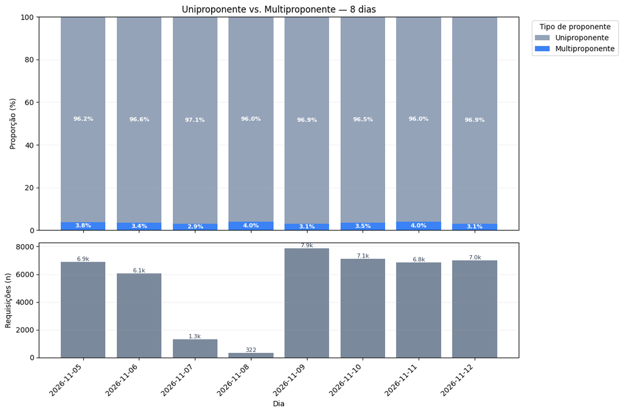

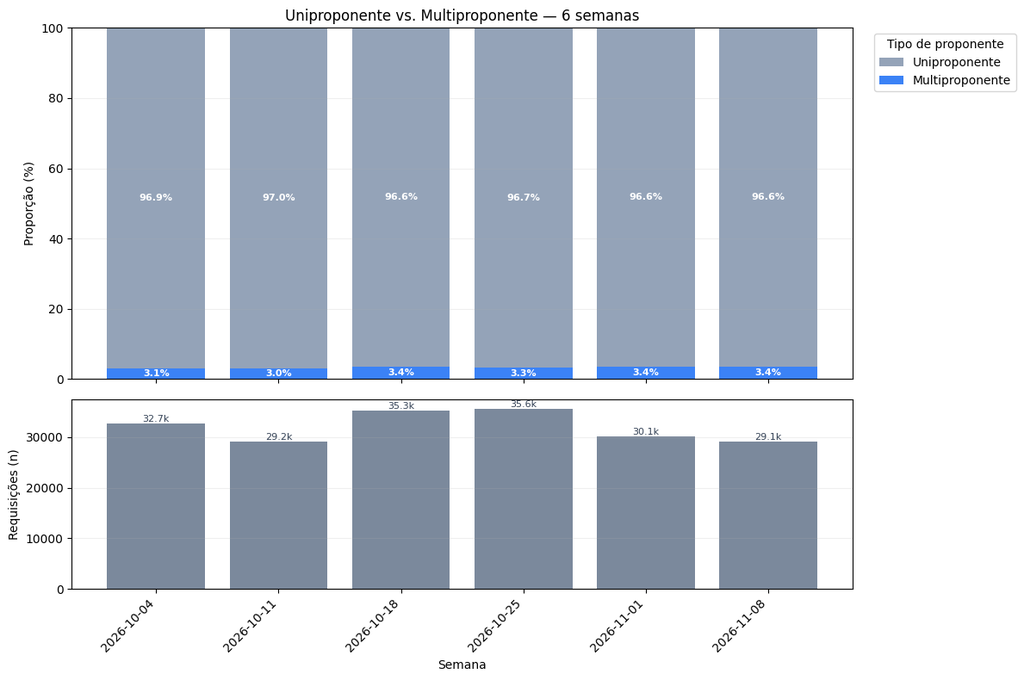

## Verificação de Cortes de Rating

Nesse caso, o que queremos é analisar se definição do Rating está sendo feita corretamente.

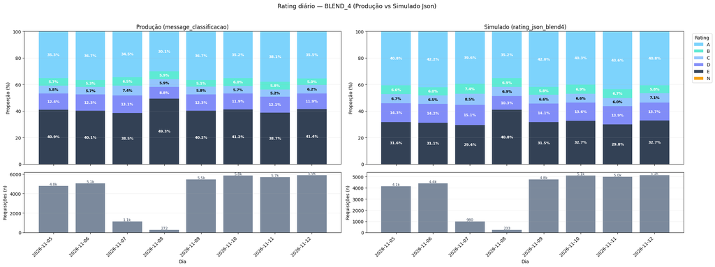

```
BLEND_4
```

| rating_json_blend4 message_classificacao | A | B | C | D | E | All |
| --- | --- | --- | --- | --- | --- | --- |
| A | 12334 | 0 | 0 | 0 | 0 | 12334 |
| B | 0 | 1886 | 0 | 0 | 0 | 1886 |
| C | 0 | 0 | 1972 | 0 | 0 | 1972 |
| D | 0 | 0 | 0 | 4142 | 0 | 4142 |
| E | 0 | 0 | 0 | 0 | 9384 | 9384 |
| All | 12334 | 1886 | 1972 | 4142 | 9384 | 29718 |

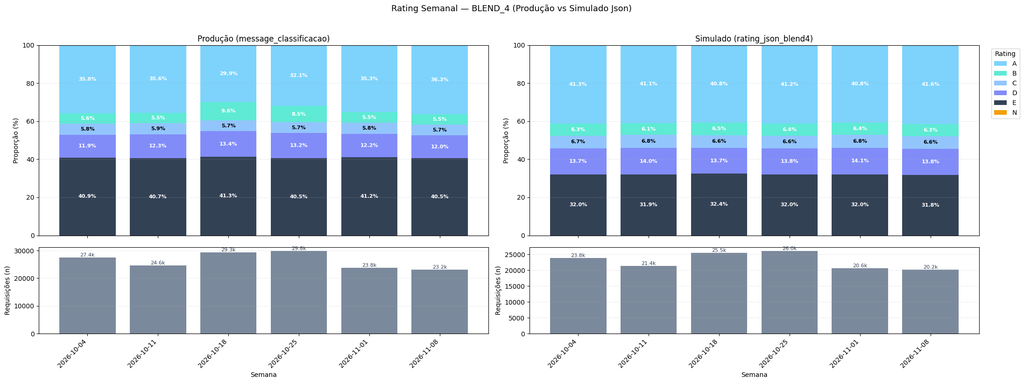

```
BLEND_4
```

| rating_json_blend4 message_classificacao | A | B | C | D | E | All |
| --- | --- | --- | --- | --- | --- | --- |
| A | 53668 | 0 | 0 | 0 | 0 | 53668 |
| B | 2889 | 7945 | 0 | 0 | 0 | 10834 |
| C | 0 | 762 | 8380 | 0 | 0 | 9142 |
| D | 0 | 0 | 798 | 19022 | 0 | 19820 |
| E | 0 | 0 | 0 | 0 | 44033 | 44033 |
| All | 56557 | 8707 | 9178 | 19022 | 44033 | 137497 |

# Salvar HTML

```
Report updated: /Users/lucas.nascimento/Monitoramento_Modelos/Monitores/02.Monitoramento_Blend4_report.html (3.64 MB) | generated at 2026-11-13 11:25:37 -03
If the browser still shows old content, hard-refresh (Cmd+Shift+R).
Report generated: /Users/lucas.nascimento/Monitoramento_Modelos/Monitores/02.Monitoramento_Blend4_report.html
```